# Introduction to Data Visualization with Seaborn

## 3.6 Adjusting the whiskers

In the lesson we saw that there are multiple ways to define the whiskers in a box plot. In this set of exercises, we’ll continue to use the `student_data` dataset to compare the distribution of final grades (`"G3"`) between students who are in a romantic relationship and those that are not. We’ll use the `"romantic"` variable, which is a yes/no indicator of whether the student is in a romantic relationship.

Let’s create a box plot to look at this relationship and try different ways to define the whiskers.

We’ve already imported Seaborn as `sns` and `matplotlib.pyplot` as `plt`.

**Instructions**

Adjust the code to make the box plot whiskers to extend to 0.5 * IQR. Recall: the IQR is the interquartile range.

Change the code to set the whiskers to extend to the 5th and 95th percentiles.

Change the code to set the whiskers to extend to the min and max values.

**Answer**

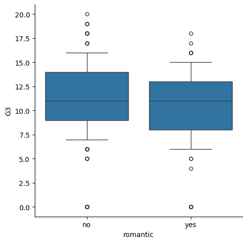

```python
# Set the whiskers to 0.5 * IQR
sns.catplot(x="romantic", y="G3",
            data=student_data,
            kind="box",
            whis=0.5)
```

```python
plt.close()  # added/edited
```

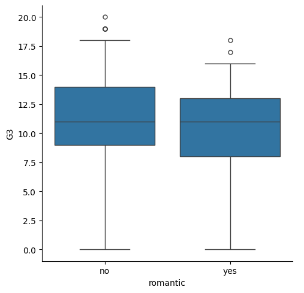

```python
# Extend the whiskers to the 5th and 95th percentile
sns.catplot(x="romantic", y="G3",
            data=student_data,
            kind="box",
            whis=[5, 95])
```

```python
plt.close()  # added/edited
```

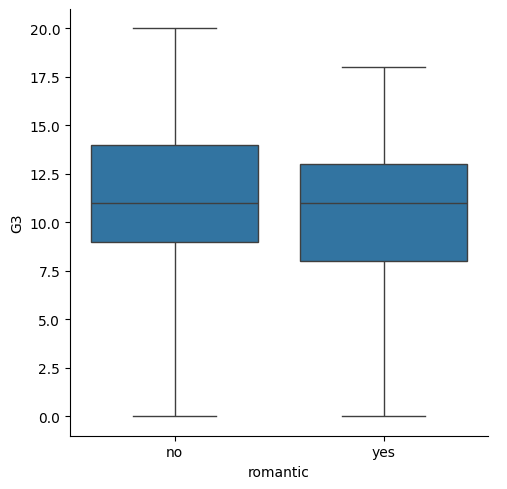

```python
# Set the whiskers at the min and max values
sns.catplot(x="romantic", y="G3",
            data=student_data,
            kind="box",
            whis=[0, 100])
```

```python
plt.close()  # added/edited
```

## 3.7 Customizing point plots

Let’s continue to look at data from students in secondary school, this time using a point plot to answer the question: does the quality of the student’s family relationship influence the number of absences the student has in school? Here, we’ll use the `"famrel"` variable, which describes the quality of a student’s family relationship from 1 (very bad) to 5 (very good).

As a reminder, to create a point plot, use the `catplot()` function and specify the name of the categorical variable to put on the x-axis (`x=____`), the name of the quantitative variable to summarize on the y-axis (`y=____`), the pandas DataFrame to use (`data=____`), and the type of categorical plot (`kind="point"`).

We’ve already imported Seaborn as `sns` and `matplotlib.pyplot` as `plt`.

**Instructions**

- Use `sns.catplot()` and the `student_data` DataFrame to create a point plot with `"famrel"` on the x-axis and number of absences (`"absences"`) on the y-axis.
- Add “caps” to the end of the confidence intervals with size `0.2`.
- Remove the lines joining the points in each category.

**Answer**

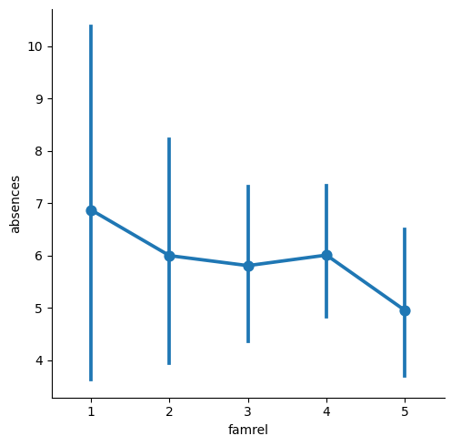

```python
# Create a point plot of family relationship vs. absences
sns.catplot(x="famrel", y="absences",
            data=student_data,
            kind="point")
```

```python
plt.close()  # added/edited
```

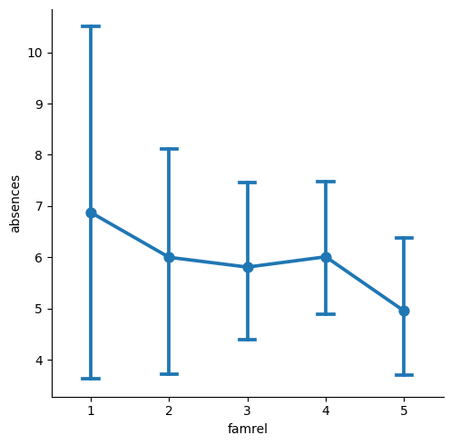

```python
# Add caps to the confidence interval
sns.catplot(x="famrel", y="absences",
            data=student_data,
            kind="point",
            capsize=0.2)
```

```python
plt.close()  # added/edited
```

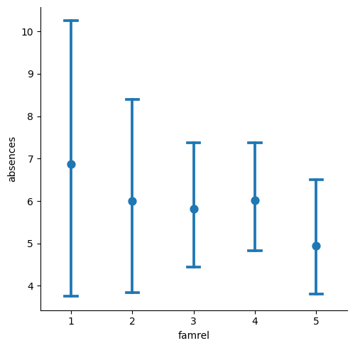

```python
# Remove the lines joining the points
sns.catplot(x="famrel", y="absences",
            data=student_data,
            kind="point",
            capsize=0.2,
            join=False)
```

```python
plt.close()  # added/edited
```

## 3.8 Point plots with subgroups

Let’s continue exploring the dataset of students in secondary school. This time, we’ll ask the question: is being in a romantic relationship associated with higher or lower school attendance? And does this association differ by which school the students attend? Let’s find out using a point plot.

We’ve already imported Seaborn as `sns` and `matplotlib.pyplot` as `plt`.

**Instructions**

- Use `sns.catplot()` and the `student_data` DataFrame to create a point plot with relationship status (`"romantic"`) on the x-axis and number of absences (`"absences"`) on the y-axis. Color the points based on the school that they attend (`"school"`).
- Turn off the confidence intervals for the plot.
- Since there may be outliers of students with many absences, use the `median` function that we’ve imported from `numpy` to display the median number of absences instead of the average.

**Answer**

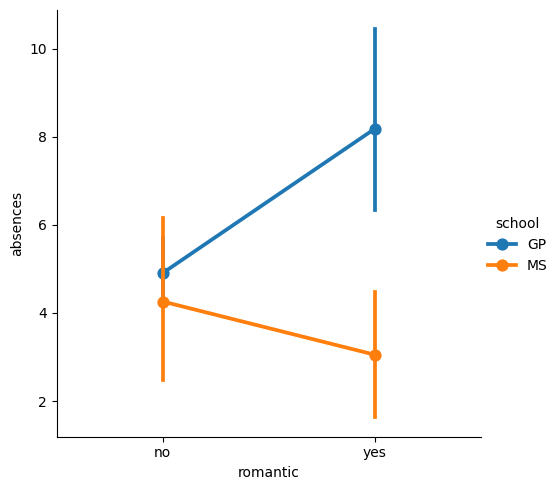

```python
# Create a point plot that uses color to create subgroups
sns.catplot(x="romantic", y="absences",
            data=student_data,
            kind="point",
            hue="school")
```

```python
plt.close()  # added/edited
```

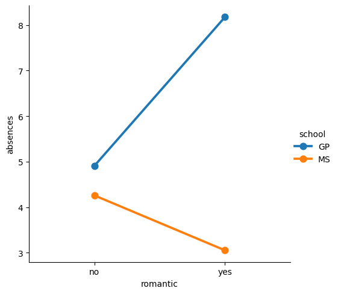

```python
# Turn off the confidence intervals for this plot
sns.catplot(x="romantic", y="absences",
            data=student_data,
            kind="point",
            hue="school",
            ci=None)
```

```python
plt.close()  # added/edited
```

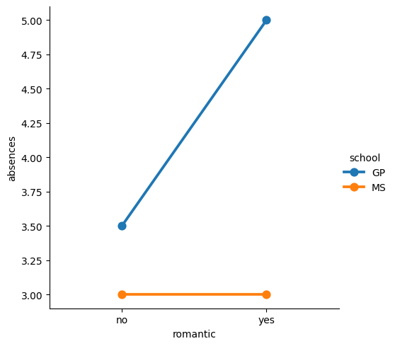

```python
# Import median function from numpy
from numpy import median

# Plot the median number of absences instead of the mean
sns.catplot(x="romantic", y="absences",
            data=student_data,
            kind="point",
            hue="school",
            ci=None,
            estimator=median)
```

```python
plt.close()  # added/edited
```

# 4 Customizing Seaborn Plots

## 4.1 Changing style and palette

Let’s return to our dataset containing the results of a survey given to young people about their habits and preferences. We’ve provided the code to create a count plot of their responses to the question “How often do you listen to your parents’ advice?”. Now let’s change the style and palette to make this plot easier to interpret.

We’ve already imported Seaborn as `sns` and `matplotlib.pyplot` as `plt`.

**Instructions**

- Set the style to `"whitegrid"` to help the audience determine the number of responses in each category.
- Set the color palette to the sequential palette named `"Purples"`.
- Change the color palette to the diverging palette named `"RdBu"`.

**Answer**

```python
# added/edited
advice_mapping = {
    1.0: "Never",
    2.0: "Rarely",
    3.0: "Sometimes",
    4.0: "Often",
    5.0: "Always",
    np.nan: np.nan  # Keeping NaN as it is
}
survey_data["Parents Advice"] = survey_data["Parents' advice"].map(advice_mapping)
```

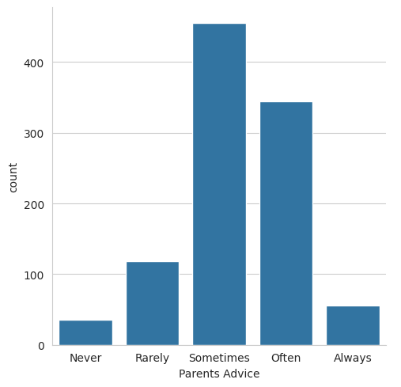

```python
# Set the style to "whitegrid"
sns.set_style("whitegrid")

# Create a count plot of survey responses
category_order = ["Never", "Rarely", "Sometimes",
                  "Often", "Always"]

sns.catplot(x="Parents Advice",
            data=survey_data,
            kind="count",
            order=category_order)
```

```python
plt.close()  # added/edited
```

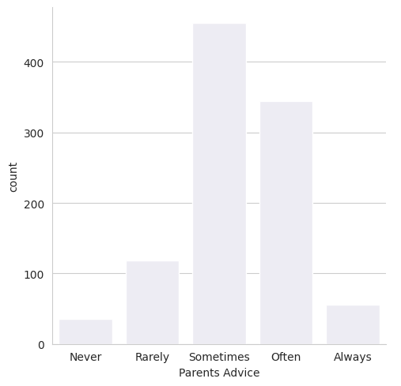

```python
# Set the color palette to "Purples"
sns.set_style("whitegrid")
sns.set_palette("Purples")

# Create a count plot of survey responses
category_order = ["Never", "Rarely", "Sometimes",
                  "Often", "Always"]

sns.catplot(x="Parents Advice",
            data=survey_data,
            kind="count",
            order=category_order)
```

```python
plt.close()  # added/edited
```

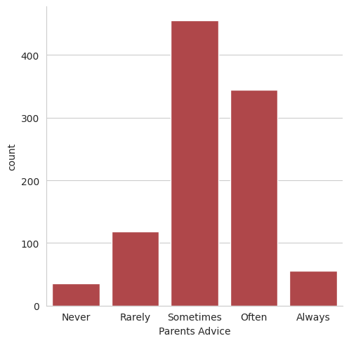

```python
# Change the color palette to "RdBu"
sns.set_style("whitegrid")
sns.set_palette("RdBu")

# Create a count plot of survey responses
category_order = ["Never", "Rarely", "Sometimes",
                  "Often", "Always"]

sns.catplot(x="Parents Advice",
            data=survey_data,
            kind="count",
            order=category_order)
```

```python
plt.close()  # added/edited
```

## 4.2 Changing the scale

In this exercise, we’ll continue to look at the dataset containing responses from a survey of young people. Does the percentage of people reporting that they feel lonely vary depending on how many siblings they have? Let’s find out using a bar plot, while also exploring Seaborn’s four different plot scales (“contexts”).

We’ve already imported Seaborn as `sns` and `matplotlib.pyplot` as `plt`.

**Instructions**

Set the scale (“context”) to `"paper"`, which is the smallest of the scale options.

Change the context to `"notebook"` to increase the scale.

Change the context to `"talk"` to increase the scale.

Change the context to `"poster"`, which is the largest scale available.

**Answer**

```python
# added/edited
survey_data = pd.read_csv("survey_data_scale.csv")
```

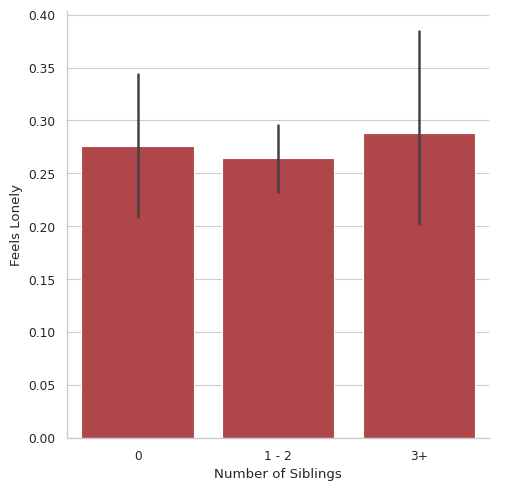

```python
# Set the context to "paper"
sns.set_context("paper")

# Create bar plot
sns.catplot(x="Number of Siblings", y="Feels Lonely",
            data=survey_data, kind="bar")
```

```python
plt.close()  # added/edited
```

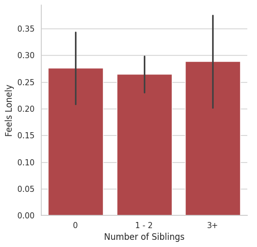

```python
# Change the context to "notebook"
sns.set_context("notebook")

# Create bar plot
sns.catplot(x="Number of Siblings", y="Feels Lonely",
            data=survey_data, kind="bar")
```

```python
plt.close()  # added/edited
```

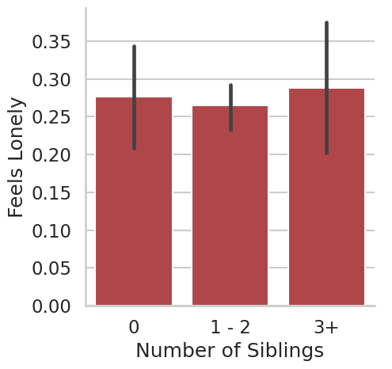

```python
# Change the context to "talk"
sns.set_context("talk")

# Create bar plot
sns.catplot(x="Number of Siblings", y="Feels Lonely",
            data=survey_data, kind="bar")
```

```python
plt.close()  # added/edited
```

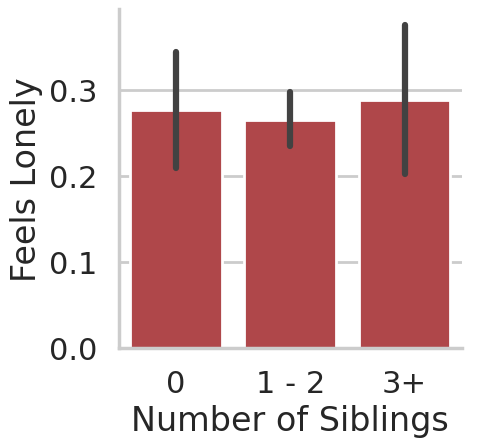

```python
# Change the context to "poster"
sns.set_context("poster")

# Create bar plot
sns.catplot(x="Number of Siblings", y="Feels Lonely",
            data=survey_data, kind="bar")
```

```python
plt.close()  # added/edited
```

## 4.3 Using a custom palette

So far, we’ve looked at several things in the dataset of survey responses from young people, including their internet usage, how often they listen to their parents, and how many of them report feeling lonely. However, one thing we haven’t done is a basic summary of the type of people answering this survey, including their age and gender. Providing these basic summaries is always a good practice when dealing with an unfamiliar dataset.

The code provided will create a box plot showing the distribution of ages for male versus female respondents. Let’s adjust the code to customize the appearance, this time using a custom color palette.

We’ve already imported Seaborn as `sns` and `matplotlib.pyplot` as `plt`.

**Instructions**

- Set the style to `"darkgrid"`.
- Set a custom color palette with the hex color codes `"#39A7D0"` and `"#36ADA4"`.

**Answer**

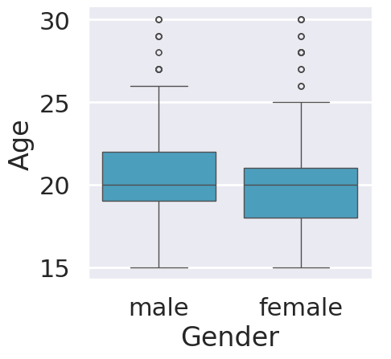

```python
# Set the style to "darkgrid"
sns.set_style("darkgrid")

# Set a custom color palette
sns.set_palette(["#39A7D0", "#36ADA4"])

# Create the box plot of age distribution by gender
sns.catplot(x="Gender", y="Age",
            data=survey_data, kind="box")
```

```python
plt.close()  # added/edited
```

## 4.4 FacetGrids vs. AxesSubplots

In the recent lesson, we learned that Seaborn plot functions create two different types of objects: `FacetGrid` objects and `AxesSubplot` objects. The method for adding a title to your plot will differ depending on the type of object it is.

In the code provided, we’ve used `relplot()` with the miles per gallon dataset to create a scatter plot showing the relationship between a car’s weight and its horsepower. This scatter plot is assigned to the variable name `g`. Let’s identify which type of object it is.

We’ve already imported Seaborn as `sns` and `matplotlib.pyplot` as `plt`.

**Instructions**

- Identify what type of object plot `g` is and assign it to the variable `type_of_g`.

**Answer**

```python
# Create scatter plot
g = sns.relplot(x="weight",
                y="horsepower",
                data=mpg,
                kind="scatter")

# Identify plot type
type_of_g = type(g)

# Print type
plt.close()  # added/edited
print(type_of_g)
```

```
## <class 'seaborn.axisgrid.FacetGrid'>
```

## 4.5 Adding a title to a FacetGrid object

In the previous exercise, we used `relplot()` with the miles per gallon dataset to create a scatter plot showing the relationship between a car’s weight and its horsepower. This created a `FacetGrid` object. Now that we know what type of object it is, let’s add a title to this plot.

We’ve already imported Seaborn as `sns` and `matplotlib.pyplot` as `plt`.

**Instructions**

- Add the following title to this plot: `"Car Weight vs. Horsepower"`.

**Answer**

```python
# added/edited
sns.reset_defaults()
```

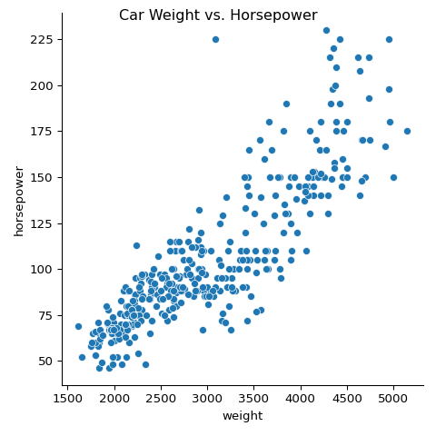

```python
# Create scatter plot
g = sns.relplot(x="weight",
                y="horsepower",
                data=mpg,
                kind="scatter")

# Add a title "Car Weight vs. Horsepower"
g.fig.suptitle("Car Weight vs. Horsepower")

# Show plot
plt.show()
```

## 4.6 Adding a title and axis labels

Let’s continue to look at the miles per gallon dataset. This time we’ll create a line plot to answer the question: How does the average miles per gallon achieved by cars change over time for each of the three places of origin? To improve the readability of this plot, we’ll add a title and more informative axis labels.

In the code provided, we create the line plot using the `lineplot()` function. Note that `lineplot()` does not support the creation of subplots, so it returns an `AxesSubplot` object instead of an `FacetGrid` object.

We’ve already imported Seaborn as `sns` and `matplotlib.pyplot` as `plt`.

**Instructions**

- Add the following title to the plot: `"Average MPG Over Time"`.
- Label the x-axis as `"Car Model Year"` and the y-axis as `"Average MPG"`.

**Answer**

```python
# added/edited
mpg_mean = mpg.groupby(["model_year", "origin"]).agg(mpg_mean=("mpg", "mean")).reset_index()
```

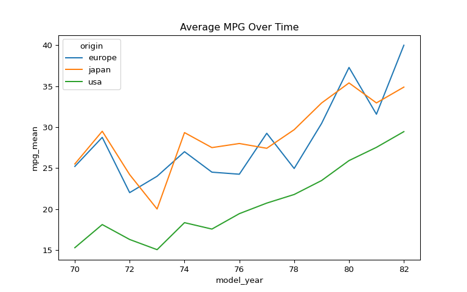

```python
# Create line plot
g = sns.lineplot(x="model_year", y="mpg_mean",
                 data=mpg_mean,
                 hue="origin")

# Add a title "Average MPG Over Time"
g.set_title("Average MPG Over Time")

# Show plot
plt.show()
```

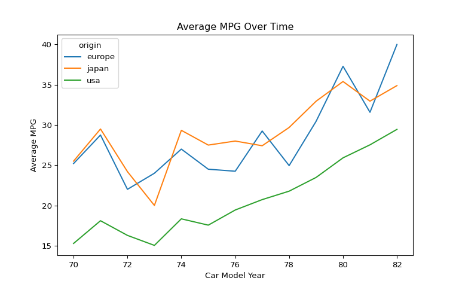

```python
# Create line plot
g = sns.lineplot(x="model_year", y="mpg_mean",
                 data=mpg_mean,
                 hue="origin")

# Add a title "Average MPG Over Time"
g.set_title("Average MPG Over Time")

# Add x-axis and y-axis labels
g.set(xlabel="Car Model Year",
      ylabel="Average MPG")

# Show plot
plt.show()
```

## 4.7 Rotating x-tick labels

In this exercise, we’ll continue looking at the miles per gallon dataset. In the code provided, we create a point plot that displays the average acceleration for cars in each of the three places of origin. Note that the `"acceleration"` variable is the time to accelerate from 0 to 60 miles per hour, in seconds. Higher values indicate slower acceleration.

Let’s use this plot to practice rotating the x-tick labels. Recall that the function to rotate x-tick labels is a standalone Matplotlib function and not a function applied to the plot object itself.

We’ve already imported Seaborn as `sns` and `matplotlib.pyplot` as `plt`.

**Instructions**

- Rotate the x-tick labels 90 degrees.

**Answer**

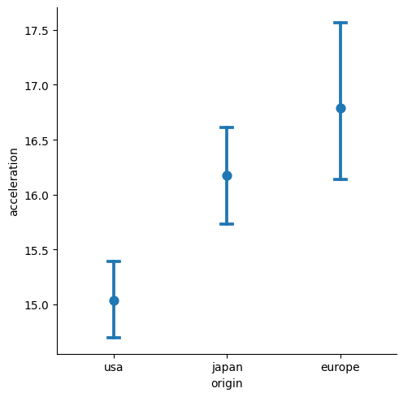

```python
# Create point plot
sns.catplot(x="origin",
            y="acceleration",
            data=mpg,
            kind="point",
            join=False,
            capsize=0.1)
```

```python
# Rotate x-tick labels
plt.xticks(rotation=90)
```

```
## ([0, 1, 2], [Text(0, 0, 'usa'), Text(1, 0, 'japan'), Text(2, 0, 'europe')])
```

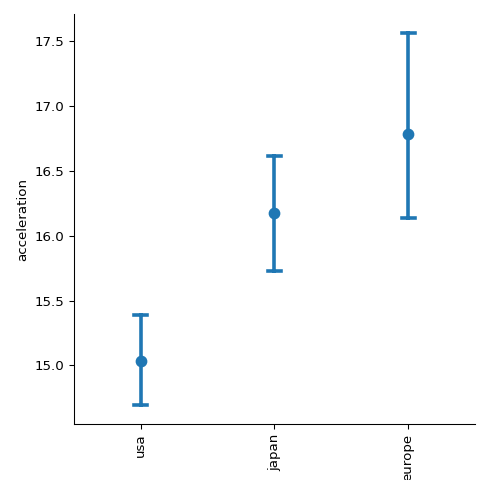

```python
# Show plot
plt.show()
```

## 4.8 Box plot with subgroups

In this exercise, we’ll look at the dataset containing responses from a survey given to young people. One of the questions asked of the young people was: “Are you interested in having pets?” Let’s explore whether the distribution of ages of those answering “yes” tends to be higher or lower than those answering “no”, controlling for gender.

**Instructions**

- Set the color palette to `"Blues"`.
- Add subgroups to color the box plots based on `"Interested in Pets"`.
- Set the title of the `FacetGrid` object `g` to `"Age of Those Interested in Pets vs. Not"`.
- Make the plot display using a Matplotlib function.

**Answer**

```python
# added/edited
survey_data = pd.read_csv("survey_data.csv")
```

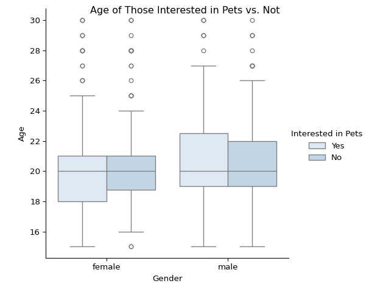

```python
# Set palette to "Blues"
sns.set_palette("Blues")

# Adjust to add subgroups based on "Interested in Pets"
g = sns.catplot(x="Gender",
                y="Age", data=survey_data,
                kind="box", hue="Interested in Pets")

# Set title to "Age of Those Interested in Pets vs. Not"
g.fig.suptitle("Age of Those Interested in Pets vs. Not")

# Show plot
plt.show()
```

## 4.9 Bar plot with subgroups and subplots

In this exercise, we’ll return to our young people survey dataset and investigate whether the proportion of people who like techno music (`"Likes Techno"`) varies by their gender (`"Gender"`) or where they live (`"Village - town"`). This exercise will give us an opportunity to practice the many things we’ve learned throughout this course!

We’ve already imported Seaborn as `sns` and `matplotlib.pyplot` as `plt`.

**Instructions**

- Set the figure style to `"dark"`.
- Adjust the bar plot code to add subplots based on `"Gender"`, arranged in columns.
- Add the title `"Percentage of Young People Who Like Techno"` to this `FacetGrid` plot.
- Label the x-axis `"Location of Residence"` and y-axis `"% Who Like Techno"`.

**Answer**

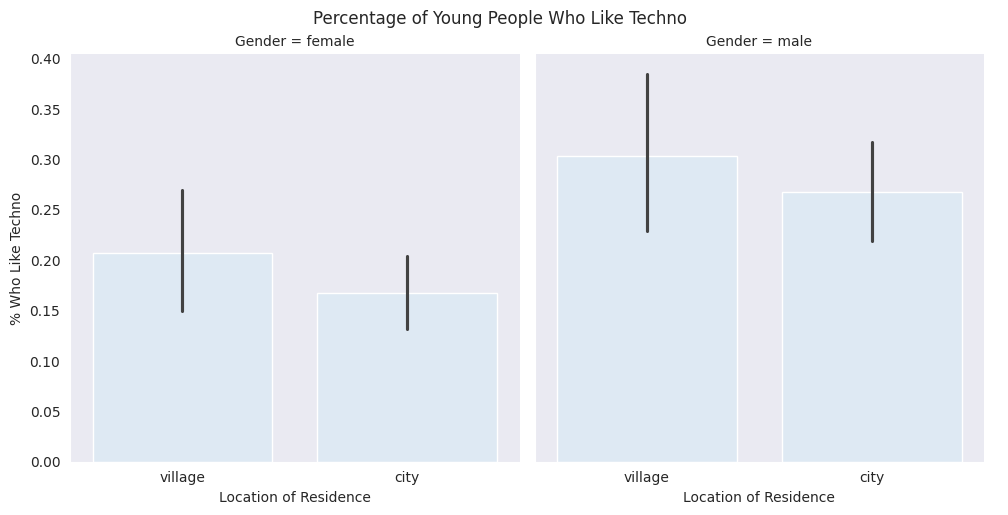

```python
# Set the figure style to "dark"
sns.set_style("dark")

# Adjust to add subplots per gender
g = sns.catplot(x="Village - town", y="Likes Techno",
                data=survey_data, kind="bar",
                col="Gender")

# Add title and axis labels
g.fig.suptitle("Percentage of Young People Who Like Techno", y=1.02)
g.set(xlabel="Location of Residence",
      ylabel="% Who Like Techno")
```

```python
plt.close()  # added/edited
```